# Analyzing Forest Fire Data

Dennis Jonathan

5/6/2021

For this exercise, we are applying what we have learned before about data visualization and other previous materials to explore a dataset of forest fires. Forest fires can create ecological problems and endanger human lives and property. Understanding when they occur and what causes them is important for managing them. The data we’ll be working with in this guided project is associated with [a scientific research paper](http://www3.dsi.uminho.pt/pcortez/fires.pdf) on predicting the occurrence of forest fires in Portugal using modeling techniques.

We will not use any type of modeling on this project, but rather we’ll focus on visualizing it. In this project, though, we’ll perform exploratory analyses on the data to better understand it and any relationships that might be present in it. Remember, exploring data visually is often the first step data scientists take when working with new data.

The data set is available [here](https://archive.ics.uci.edu/ml/machine-learning-databases/forest-fires/). Without further ado, let’s begin!

### Prerequisites

```r
# Shutting off warning messages
options(warn=-1)

# Importing tidyverse
library(tidyverse)
# Importing lubridate
library(lubridate)
# Importing our dataset
df <- read_csv('forestfires.csv')
```

### Initial Exploration

```r
# Previewing the first five data
head(df,5)
```

```
## # A tibble: 5 x 13
##       X     Y month day    FFMC   DMC    DC   ISI  temp    RH  wind  rain  area
##   <dbl> <dbl> <chr> <chr> <dbl> <dbl> <dbl> <dbl> <dbl> <dbl> <dbl> <dbl> <dbl>
## 1     7     5 mar   fri    86.2  26.2  94.3   5.1   8.2    51   6.7   0       0
## 2     7     4 oct   tue    90.6  35.4 669.    6.7  18      33   0.9   0       0
## 3     7     4 oct   sat    90.6  43.7 687.    6.7  14.6    33   1.3   0       0
## 4     8     6 mar   fri    91.7  33.3  77.5   9     8.3    97   4     0.2     0
## 5     8     6 mar   sun    89.3  51.3 102.    9.6  11.4    99   1.8   0       0
```

```r
# Finding the dimension of the data
dim(df)
```

```
## [1] 517  13
```

```r
# Finding the column names
colnames(df)
```

```
##  [1] "X"     "Y"     "month" "day"   "FFMC"  "DMC"   "DC"    "ISI"   "temp"
## [10] "RH"    "wind"  "rain"  "area"
```

We can see that there are 517 rows and 13 columns that we can explore, those columns are:

- `X`: X-axis spatial coordinate within the Montesinho park map: 1 to 9
- `Y`: Y-axis spatial coordinate within the Montesinho park map: 2 to 9
- `month`: Month of the year: ‘jan’ to ‘dec’
- `day`: Day of the week: ‘mon’ to ‘sun’
- `FFMC`: Fine Fuel Moisture Code index from the FWI system: 18.7 to 96.20
- `DMC`: Duff Moisture Code index from the FWI system: 1.1 to 291.3
- `DC`: Drought Code index from the FWI system: 7.9 to 860.6
- `ISI`: Initial Spread Index from the FWI system: 0.0 to 56.10
- `temp`: Temperature in Celsius degrees: 2.2 to 33.30
- `RH`: Relative humidity in percentage: 15.0 to 100
- `wind`: Wind speed in km/h: 0.40 to 9.40
- `rain`: Outside rain in mm/m2 : 0.0 to 6.4
- `area`: The burned area of the forest (in ha): 0.00 to 1090.84

Each rows represent a single occurrence of forest fire complete with the coordinate, time, and some metrics that might describe the condition of the particular area at the time. A quick Google search tells us that forest fires main kryptonite is water. Intuitively we can think that water prevents the spread of fire during forest fires, thus it is safe to assume that `DMC` and `rain` might be correlated to `area`.

### Data Processing

Now we have reached the somewhat laborious step which is tweaking the data to help us gain more insights out of it. The first thing that we are going to do is to convert `month` and `day` into categorical data. We can do that by using the `factor()` function, but before doing that, we need to know the unique values for those columns.

```r
# Checking the unique values for the month column
df %>% pull(month) %>% unique
```

```
##  [1] "mar" "oct" "aug" "sep" "apr" "jun" "jul" "feb" "jan" "dec" "may" "nov"
```

```r
# Checking the unique values for the day column
df %>% pull(day) %>% unique
```

```
## [1] "fri" "tue" "sat" "sun" "mon" "wed" "thu"
```

Now that we have seen the unique values, we can convert them into categorical. For this instance, we can convert them base on order, so for `month`, ‘jan’ will be first and ‘dec’ will be twelfth, while for `day`, ‘mon’ will be first and ‘sun’ will be seventh.

```r
# Creating categorical columns
df <- df %>% mutate(
  month = factor(month, levels=c(
    'jan','feb','mar','apr','may','jun','jul','aug','sep','oct','nov','dec'
  )),
  day = factor(day, levels=c(
    'mon','tue','wed','thu','fri','sat','sun'
  ))
)

# Checking the change for month column
df %>% pull(month) %>% levels()
```

```
##  [1] "jan" "feb" "mar" "apr" "may" "jun" "jul" "aug" "sep" "oct" "nov" "dec"
```

```r
# Checking the change for day column
df %>% pull(day) %>% levels()
```

```
## [1] "mon" "tue" "wed" "thu" "fri" "sat" "sun"
```

### Visualization

#### 1. When does forest fires occur the most?

We will now try and find out when does forest fires occur the most in terms of month and day. To do this, we will create a separate data frame which group the data based on `month` or `day` and then count the number of rows.

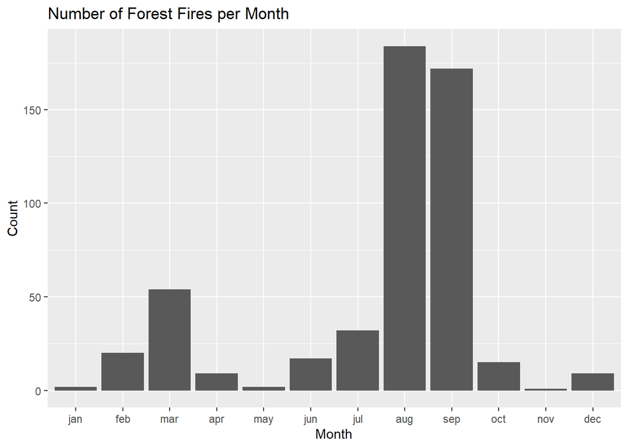

```r
# Aggregating data based on month
agg_mon <- df %>% group_by(month) %>% summarize(
  count = n()
)

# Plotting the data
agg_mon %>% ggplot(aes(x=month,y=count)) + geom_col() + labs(title='Number of Forest Fires per Month',x='Month',y='Count')
```

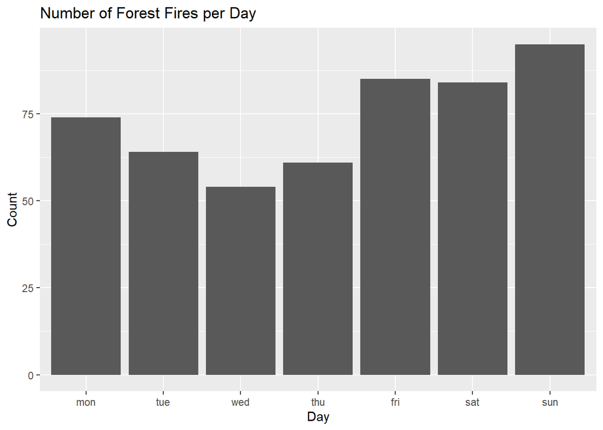

```r
# Aggregating the data based on day
agg_day <- df %>% group_by(day) %>% summarize(
  count = n()
)

# Plotting the data
agg_day %>% ggplot(aes(x=day,y=count)) + geom_col() + labs(title='Number of Forest Fires per Day',x='Day',y='Count')
```

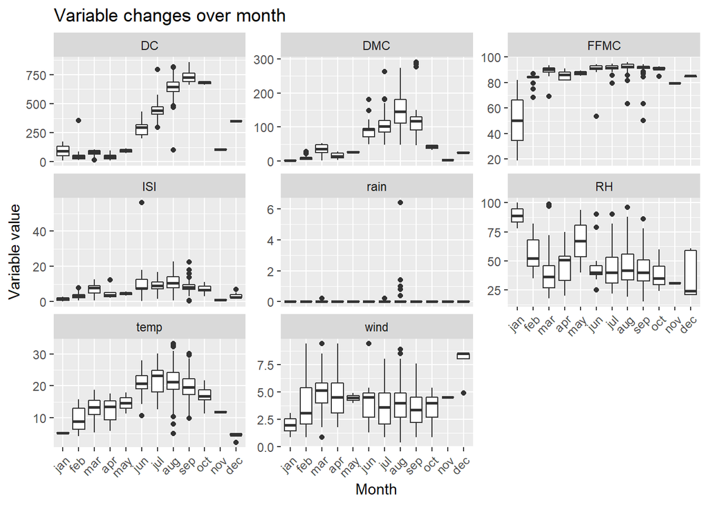

```r
# Creating a longer version of df for the other variables
df_long <- df %>%
  pivot_longer(
    cols = c("FFMC", "DMC", "DC",
             "ISI", "temp", "RH",
             "wind", "rain"),
    names_to = "data_col",
    values_to = "value"
  )

# Plotting the data frame based on month
df_long %>% ggplot(aes(x=month,y=value))+geom_boxplot()+facet_wrap(vars(data_col),scale='free_y')+ labs(
    title = "Variable changes over month",
    x = "Month",
    y = "Variable value"
  ) + theme(axis.text.x = element_text(angle = 45, hjust = 1))
```

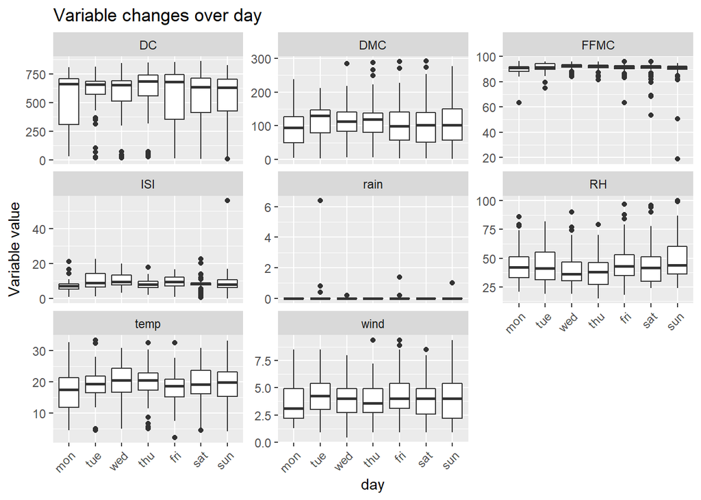

```r
# Plotting the data frame based on day
df_long %>% ggplot(aes(x=day,y=value))+geom_boxplot()+facet_wrap(vars(data_col),scale='free_y')+ labs(
    title = "Variable changes over day",
    x = "day",
    y = "Variable value"
  ) + theme(axis.text.x = element_text(angle = 45, hjust = 1))
```

#### 3. Factors influencing area burned

We will now try and find whether area burned is correlated to any of the variables that we have. To do this, we can use the help of scatter plots to show the strength of the relationship as well as the direction.

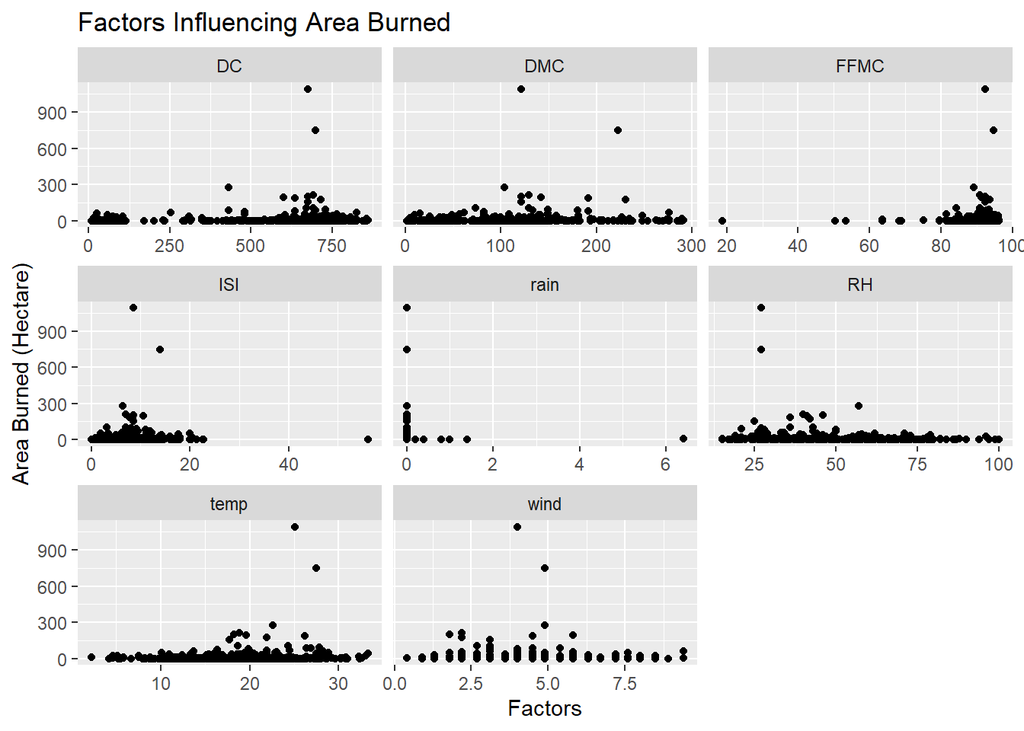

```r
# Plotting the data frame based on month
df_long %>% ggplot(aes(x=value,y=area))+geom_point()+facet_wrap(vars(data_col),scale='free_x')+ labs(
    title = "Factors Influencing Area Burned",
    x = "Factors",
    y = "Area Burned (Hectare)"
  )
```

We can see that most of the metrics might not be directly correlated to `area`, but we need to investigate it further to confirm that assumption. The graph also shows that we indeed have outliers in terms of `area` and their values are greater than about 500 Ha, thus we can filter it out and investigate again.

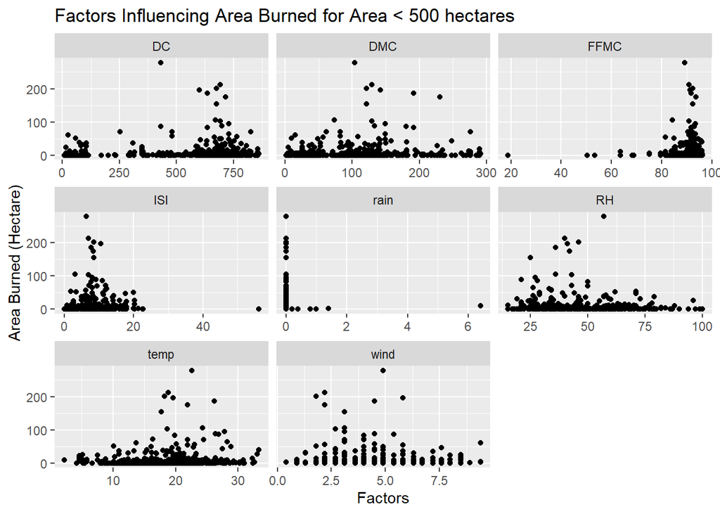

```r
df_long %>% filter(area<500) %>% ggplot(aes(x=value,y=area))+geom_point()+facet_wrap(vars(data_col),scale='free_x')+labs(
    title = "Factors Influencing Area Burned for Area < 500 hectares",
    x = "Factors",
    y = "Area Burned (Hectare)"
)
```